# Results Summary 7-10-2017

Cecina Babich Morrow

July 10, 2017

```r
library(readr)
library(lattice)
library(RColorBrewer)
library(ggplot2)
library(hypervolume)
library(tidyr)
library(taxize)
library(brranching)
library(picante)
library(ape)
library(maptools)
library(mapproj)
library(rgeos)
library(rgdal)
library(sp)
library(raster)
library(phytools)
library(geiger)
```

## Trophic Levels

I used the dataset MammalDIET (Kissling et al. 2014) to add trophic level to the mammal species. 758 of the 849 mammals with trait coverage for body mass and the three invariants had trophic level (188 carnivores, 270 omnivores, and 300 herbivores).

```r
MammalDIET_v1_0$taxaname<-paste(MammalDIET_v1_0$Genus,MammalDIET_v1_0$Species,sep="_")
completemammal_trophic<-merge(completecase_species,MammalDIET_v1_0[,c("taxaname","TrophicLevel")],by="taxaname")
```

I created hypervolumes for the carnivores, herbivores, and omnivores in order to compare them.

```r
mammalcarnivore_gaussian<-hypervolume_gaussian(data = completemammal_trophic[completemammal_trophic$TrophicLevel=="Carnivore",13:16],
                                               name = "mammalcarnivore_gaussian")
#omnivore hypervolume
mammalomnivore_gaussian<-hypervolume_gaussian(data = completemammal_trophic[completemammal_trophic$TrophicLevel=="Omnivore",13:16],
                                               name = "mammalomnivore_gaussian")
#herbivore hypervolume
mammalherbivore_gaussian<-hypervolume_gaussian(data = completemammal_trophic[completemammal_trophic$TrophicLevel=="Herbivore",13:16],
                                              name = "mammalherbivore_gaussian")
```

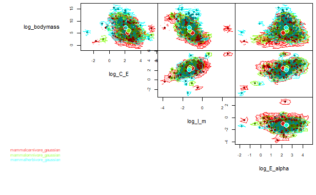

```r
plot(hypervolume_join(mammalcarnivore_gaussian,mammalomnivore_gaussian,mammalherbivore_gaussian))
```

It appears as if the carnivores and herbivores both occupy unique trait space whereas the omnivores reside primarily in the intersection of the two other trophic levels.

```r
mammalcarnivore_gaussian@Volume
```

```
[1] 241.3573
```

```r
mammalherbivore_gaussian@Volume
```

```
[1] 157.564
```

```r
mammalomnivore_gaussian@Volume
```

```
[1] 105.7706
```

The carnivore hypervolume is the largest, followed by the herbivores and omnivores.

```r
#carnivore and herbivore
hypervolume_overlap_statistics(hypervolume_set(mammalcarnivore_gaussian,mammalherbivore_gaussian,check.memory=FALSE))
```

```
Choosing num.points.max=100000 (use a larger value for more accuracy.)
Using minimum density of 210.915482
Retaining 50906 points in hv1 and 33232 points in hv2.
Beginning ball queries...

Building tree...
done.
Ball query...

done.

Building tree...
done.
Ball query...

done.
Finished ball queries.
      jaccard      sorensen frac_unique_1 frac_unique_2
    0.3670813     0.5370292     0.5561925     0.3201733
```

```r
#carnivore and omnivore
hypervolume_overlap_statistics(hypervolume_set(mammalcarnivore_gaussian,mammalomnivore_gaussian,check.memory=FALSE))
```

```
Choosing num.points.max=100000 (use a larger value for more accuracy.)
Using minimum density of 210.915482
Retaining 50906 points in hv1 and 22308 points in hv2.
Beginning ball queries...

Building tree...
done.
Ball query...

done.

Building tree...
done.
Ball query...

done.
Finished ball queries.
      jaccard      sorensen frac_unique_1 frac_unique_2
    0.3499994     0.5185178     0.6271255     0.1491393
```

```r
#herbivore and omnivore
hypervolume_overlap_statistics(hypervolume_set(mammalherbivore_gaussian,mammalomnivore_gaussian,check.memory=FALSE))
```

```
Choosing num.points.max=100000 (use a larger value for more accuracy.)
Using minimum density of 334.803674
Retaining 52753 points in hv1 and 35412 points in hv2.
Beginning ball queries...

Building tree...
done.
Ball query...

done.

Building tree...
done.
Ball query...

done.
Finished ball queries.
      jaccard      sorensen frac_unique_1 frac_unique_2
    0.4722920     0.6415738     0.4638732     0.2013442
```

From examining the overlaps, we can see that all three groups overlap quite a bit, more so than the three classes do. The carnivores have the most unique space in general. The omnivores, however, have much less unique area than either the herbivores and carnivores. These overlap values support the qualitative assessment from the graph that the omnivores occupy the intersection of the trait space of the carnivores and herbivores. To test this hypothesis, I compared the hypervolume intersection of carnivores and herbivores to the omnivore hypervolume.

```r
carnherb_set<-hypervolume_set(mammalcarnivore_gaussian,mammalherbivore_gaussian,check.memory = FALSE)
carnherb_int<-carnherb_set@HVList$Intersection
hypervolume_overlap_statistics(hypervolume_set(mammalomnivore_gaussian,carnherb_int,check.memory = FALSE))
```

[output not shown]

## Bats

I examined how bats relate to birds and mammals in terms of their life history trait space to see how their life history constraints balance being volant with being a mammal.

### Histograms

I began by creating the histograms for the bats overlaid on those for the birds and mammals.

Body mass:

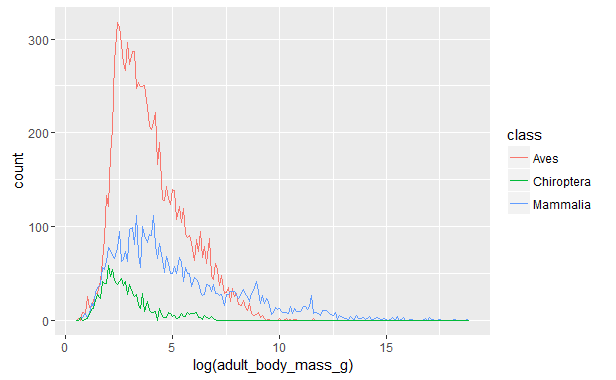

```r
ggplot(data=Amniote_Database_Aug_2015)+
  geom_freqpoly(aes(x=log(adult_body_mass_g),color=class),binwidth = 0.1,data=subset(Amniote_Database_Aug_2015,class=="Aves"))+
  geom_freqpoly(aes(x=log(adult_body_mass_g),color=class),binwidth = 0.1,data=subset(Amniote_Database_Aug_2015,class=="Mammalia"))+
  geom_freqpoly(aes(x=log(adult_body_mass_g),color=order),binwidth = 0.1,data=subset(Amniote_Database_Aug_2015,order=="Chiroptera"))
```

Bats are at the lowest end of the mammals in terms of body mass, most likely due to the constraints of flight.

$C\cdot E$:

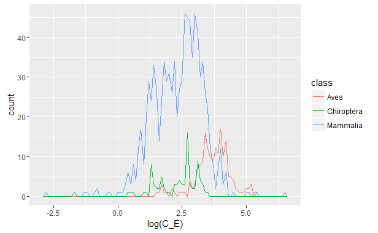

```r
ggplot(data=Amniote_Database_Aug_2015)+
  geom_freqpoly(aes(x=log(C_E),color=class),binwidth = 0.1,data=subset(Amniote_Database_Aug_2015,class=="Aves"))+
  geom_freqpoly(aes(x=log(C_E),color=class),binwidth = 0.1,data=subset(Amniote_Database_Aug_2015,class=="Mammalia"))+
  geom_freqpoly(aes(x=log(C_E),color=order),binwidth = 0.1,data=subset(Amniote_Database_Aug_2015,order=="Chiroptera"))
```

In terms of $C\cdot E$, the distribution of bats appears more similar to that of mammals as a whole than it does to the birds. Bats have a reproduction per unit death representative of the general mammal values, which are slightly lower than those of birds.

$E/ \alpha$:

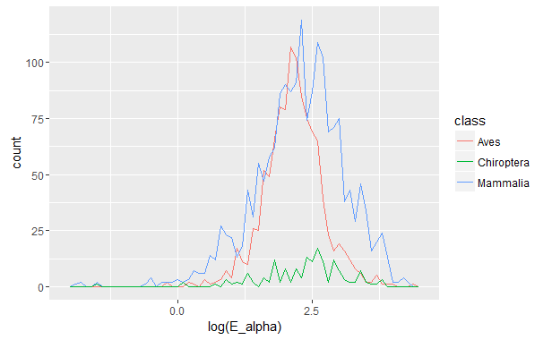

```r
ggplot(data=Amniote_Database_Aug_2015)+
  geom_freqpoly(aes(x=log(E_alpha),color=class),binwidth = 0.1,data=subset(Amniote_Database_Aug_2015,class=="Aves"))+
  geom_freqpoly(aes(x=log(E_alpha),color=class),binwidth = 0.1,data=subset(Amniote_Database_Aug_2015,class=="Mammalia"))+
  geom_freqpoly(aes(x=log(E_alpha),color=order),binwidth = 0.1,data=subset(Amniote_Database_Aug_2015,order=="Chiroptera"))
```

The distributions of $E/ \alpha$ for birds and mammals are fairly similar, so the bats are similar to both classes for this trait.

$I/m$:

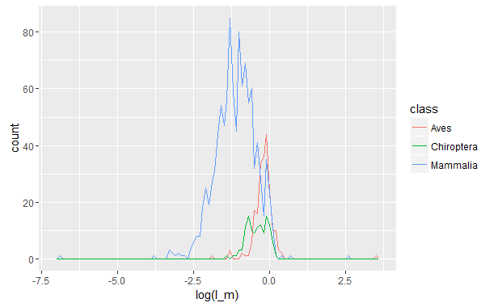

```r
ggplot(data=Amniote_Database_Aug_2015)+
  geom_freqpoly(aes(x=log(I_m),color=class),binwidth = 0.1,data=subset(Amniote_Database_Aug_2015,class=="Aves"))+
  geom_freqpoly(aes(x=log(I_m),color=class),binwidth = 0.1,data=subset(Amniote_Database_Aug_2015,class=="Mammalia"))+
  geom_freqpoly(aes(x=log(I_m),color=order),binwidth = 0.1,data=subset(Amniote_Database_Aug_2015,order=="Chiroptera"))
```

The $I/m$ values of bats appear to be constrained in the same way as those of the birds. Both bats and birds have a narrower range of $I/m$ values than mammals do, and these values are at the higher end.

### Hypervolumes

Next, I overlaid the bat data points on the hypervolumes for the birds and mammals. In order to do this, I needed to first reorder the columns of my data so that plot.function.additional works correctly.

```r
complete_data<-completecase_species[,c(12:15,1:5)]
complete_data<-as.data.frame(complete_data)
```

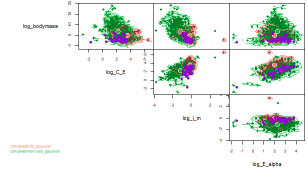

```r
plot(hypervolume_join(completebirds_gaussian,completemammals_gaussian),colors=c(gg_color_hue(3)[1],gg_color_hue(3)[2]),plot.function.additional=function(i,j) {
  points(x=complete_data[complete_data$order=="Chiroptera",i],y=complete_data[complete_data$order=="Chiroptera",j],col="darkviolet",pch=19)
})
```

The purple points show the location of the bat data relative to the bird and mammal hypervolumes. The similarities and differences from the histograms are also evident in the hypervolumes. The bats have low body masses and have constraints on $I/m$ similar to the birds. Their $C/E$ values, however, are more similar to the mammals.

I also created a separate hypervolume for the bats to compare overlap metrics to the mammal and bird hypervolumes.

```r
completebats_gaussian<-hypervolume_gaussian(data = completecase_species[completecase_species$order=="Chiroptera",12:15],
                                                name = "completebats_gaussian")
#Birds and bats:
hypervolume_overlap_statistics(hypervolume_set(completebirds_gaussian,completebats_gaussian,check.memory = FALSE))
#Mammals and bats:
hypervolume_overlap_statistics(hypervolume_set(completemammals_gaussian,completebats_gaussian,check.memory = FALSE))
```

```r
#Birds and bats:
hypervolume_overlap_statistics(hypervolume_set(completebirds_gaussian,completebats_gaussian,check.memory = FALSE))
```

```
Choosing num.points.max=100000 (use a larger value for more accuracy.)
Using minimum density of 1319.768933
Retaining 50665 points in hv1 and 51653 points in hv2.
Beginning ball queries...

Building tree...
done.
Ball query...

done.

Building tree...
done.
Ball query...

done.
Finished ball queries.
      jaccard      sorensen frac_unique_1 frac_unique_2
    0.1031363     0.1869874     0.8111877     0.8148026
```

```r
#Mammals and bats:
hypervolume_overlap_statistics(hypervolume_set(completemammals_gaussian,completebats_gaussian,check.memory = FALSE))
```

```
Choosing num.points.max=100000 (use a larger value for more accuracy.)
Using minimum density of 238.252773
Retaining 48975 points in hv1 and 9324 points in hv2.
Beginning ball queries...

Building tree...
done.
Ball query...

done.

Building tree...
done.
Ball query...

done.
Finished ball queries.
      jaccard      sorensen frac_unique_1 frac_unique_2
    0.1621831     0.2791008     0.8338791     0.1275204
```

Clearly the bat hypervolume is more similar to that of mammals than that of birds since bats are included in the mammal hypervolume. Bats are more similar to birds than mammals as a whole are, however (0.187 vs. 0.143 Sorensen overlap).

## Primates

I also examined the histograms of primate traits relative to the three classes, expecting to find that primates had different constraints than the mammals as a whole. This was not the case, however; primates had very similar ranges of trait values to all mammals.

In somewhat of a sidetrack, I looked at how primates differ in their value of $A$ as defined in Charnov (1993) Chapter 5. If $W$ is body mass and $T$ is time, then $\frac{dW}{dT}=AW^{0.75}$. $A$ can be calculated by regressing $\ln(\alpha)$ on $\ln(W)$.

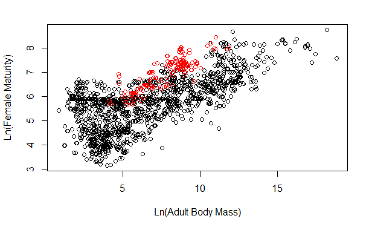

```r
A_mammals<-Amniote_Database_Aug_2015[which(!is.na(Amniote_Database_Aug_2015$female_maturity_d) & !is.na(Amniote_Database_Aug_2015$adult_body_mass_g) & Amniote_Database_Aug_2015$class=="Mammalia"),]
plot(log(A_mammals$female_maturity_d)~log(A_mammals$adult_body_mass_g),ylab="Ln(Female Maturity)",xlab="Ln(Adult Body Mass)")
points(log(A_mammals$female_maturity_d[A_mammals$order=="Primates"])~log(A_mammals$adult_body_mass_g[A_mammals$order=="Primates"]),col="red")
```

The red datapoints highlight the position of the primates relative to the other mammals.

```r
A_mammals_noprimates<-Amniote_Database_Aug_2015[which(!is.na(Amniote_Database_Aug_2015$female_maturity_d) & !is.na(Amniote_Database_Aug_2015$adult_body_mass_g) & !is.na(Amniote_Database_Aug_2015$weaning_d) & Amniote_Database_Aug_2015$class=="Mammalia" & Amniote_Database_Aug_2015$order!="Primates"),]
A_model_noprimates<-lm(log(A_mammals_noprimates$female_maturity_d)~log(A_mammals_noprimates$adult_body_mass_g))
summary(A_model_noprimates)
```

```
Call:
lm(formula = log(A_mammals_noprimates$female_maturity_d) ~ log(A_mammals_noprimates$adult_body_mass_g))

Residuals:
     Min       1Q   Median       3Q      Max
-1.94193 -0.59412 -0.01731  0.59322  2.07353

Coefficients:
                                            Estimate Std. Error t value
(Intercept)                                 4.154343   0.042379   98.03
log(A_mammals_noprimates$adult_body_mass_g) 0.222809   0.005933   37.55
                                            Pr(>|t|)
(Intercept)                                   <2e-16 ***
log(A_mammals_noprimates$adult_body_mass_g)   <2e-16 ***
---
Signif. codes:  0 ‘***’ 0.001 ‘**’ 0.01 ‘*’ 0.05 ‘.’ 0.1 ‘ ’ 1

Residual standard error: 0.7739 on 1455 degrees of freedom
Multiple R-squared:  0.4922,    Adjusted R-squared:  0.4918
F-statistic:  1410 on 1 and 1455 DF,  p-value: < 2.2e-16
```

Charnov reports an intercept of about 4.1 and a slope of about 0.25 for a regression on mammals without primates using the units of grams and days, so I am in the ballpark.

```r
A_model_primates<-lm(log(A_mammals$female_maturity_d[A_mammals$order=="Primates"])~log(A_mammals$adult_body_mass_g[A_mammals$order=="Primates"]))
summary(A_model_primates)
```

```
Call:
lm(formula = log(A_mammals$female_maturity_d[A_mammals$order ==
    "Primates"]) ~ log(A_mammals$adult_body_mass_g[A_mammals$order ==
    "Primates"]))

Residuals:
     Min       1Q   Median       3Q      Max
-0.98918 -0.20472 -0.05373  0.21625  1.02847

Coefficients:
                                                                Estimate
(Intercept)                                                      4.23657
log(A_mammals$adult_body_mass_g[A_mammals$order == "Primates"])  0.35207
                                                                Std. Error
(Intercept)                                                        0.10370
log(A_mammals$adult_body_mass_g[A_mammals$order == "Primates"])    0.01308
                                                                t value
(Intercept)                                                       40.85
log(A_mammals$adult_body_mass_g[A_mammals$order == "Primates"])   26.92
                                                                Pr(>|t|)
(Intercept)                                                       <2e-16
log(A_mammals$adult_body_mass_g[A_mammals$order == "Primates"])   <2e-16

(Intercept)                                                     ***
log(A_mammals$adult_body_mass_g[A_mammals$order == "Primates"]) ***
---
Signif. codes:  0 ‘***’ 0.001 ‘**’ 0.01 ‘*’ 0.05 ‘.’ 0.1 ‘ ’ 1

Residual standard error: 0.3321 on 279 degrees of freedom
Multiple R-squared:  0.722, Adjusted R-squared:  0.721
F-statistic: 724.6 on 1 and 279 DF,  p-value: < 2.2e-16
```

This slope is very similar to the 0.34 reported by Charnov for just primates. Primates thus have very different $A$ values from mammals as a whole. Since they have higher slopes, they have lower $A$ values, which means that they have slower growth than other mammal species. This is not directly related to any of the invariant traits, but I thought it was interesting to note.

## Bird Orders

I looked at each of the bird orders and examined their placement relative to the bird hypervolume as a whole. There were three orders that had more than 5 species with complete trait coverage: Passeriformes (plotted in green), Charadriiformes (red), and Procellariformes (blue).

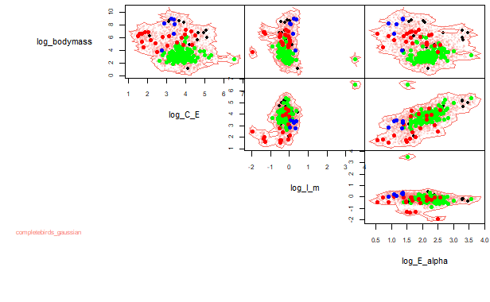

```r
plot(completebirds_gaussian,point.dark.factor=1,color=gg_color_hue(3)[1],
     plot.function.additional=function(i,j) {
       points(x=complete_data[complete_data$order=="Passeriformes",i],y=complete_data[complete_data$order=="Passeriformes",j],col="green",pch=19)
       points(x=complete_data[complete_data$order=="Charadriiformes",i],y=complete_data[complete_data$order=="Charadriiformes",j],col="red",pch=19)
       points(x=complete_data[complete_data$order=="Procellariiformes",i],y=complete_data[complete_data$order=="Procellariiformes",j],col="blue",pch=19)
     })
```

The three orders had fairly noticeable separation in body mass. The Passeriformes tended to be clustered in trait space, while the Charadriiformes were more scattered throughout. We did not have very many Procellariformes with complete trait coverage, but those that we had tended to be towards the edges of the hypervolume, with high $I/m$ and low $E/\alpha$ values.

## Reptile Orders

I also visualized the three reptile orders in relation to the entire reptile hypervolume.

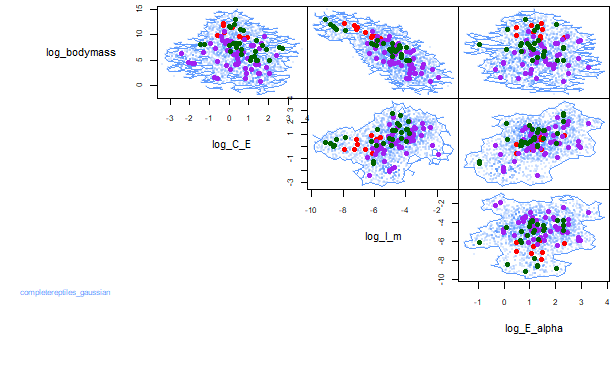

```r
plot(completereptiles_gaussian,point.dark.factor=1,color=gg_color_hue(3)[3],
     plot.function.additional=function(i,j) {
       points(x=complete_data[complete_data$order=="Crocodilia",i],y=complete_data[complete_data$order=="Crocodilia",j],col="red",pch=19)
       points(x=complete_data[complete_data$order=="Squamata",i],y=complete_data[complete_data$order=="Squamata",j],col="purple",pch=19)
       points(x=complete_data[complete_data$order=="Testudines",i],y=complete_data[complete_data$order=="Testudines",j],col="darkgreen",pch=19)
     })
```

Crocodilia is plotted in red, Squamata in purple, and Testudines in green. There is some clustering, but it is not incredibly well-defined. The orders appear to be most partitioned along the $I/m$ axis.

## Phylogenetic Analyses

### Birds

I am struggling to find an avian phylogeny that has branch lengths and is also ultrametric. I am continuing to look through literature for something that meets these requirements.

### Mammals

I used a mammal supertree downloaded from Fritz et al. 2009 and pruned it to include only the species for which we have values for body mass and the three invariants.

```r
mammaltrees<-read.nexus("fritztree2009.txt")
#Pick just the tree with the best date estimate
mammaltree_best<-mammaltrees$mammalST_MSW05_bestDates
#named vector including all the mammal species with complete trait data
bmvec_mammal<-completecase_species$adult_body_mass_g[completecase_species$class=="Mammalia"]
names(bmvec_mammal)<-completecase_species$taxaname[completecase_species$class=="Mammalia"]
#Pruned to just the mammals with trait data
pruned_mammaltree_best<-prune.missing(x=bmvec_mammal, phylo=mammaltree_best)
pruned_mammaltree_best<-pruned_mammaltree_best$tree
```

There are 849 mammal species with complete trait coverage and 834 of those species are represented in this tree.

We can visualize body mass and the three invariant traits on this tree using a color scale.

Body mass:

```r
mammal_log_bodymass<-completecase_species$log_bodymass[completecase_species$class=="Mammalia"]
names(mammal_log_bodymass)<-completecase_species$taxaname[completecase_species$class=="Mammalia"]
mammal_log_bodymass_tiporder<-mammal_log_bodymass[pruned_mammaltree_best$tip.label]
plot(pruned_mammaltree_best,no.margin = TRUE,type="fan",show.tip.label = FALSE)
tiplabels(pch=19,col=color.scale(mammal_log_bodymass_tiporder,extremes=c("blue","red")))
```

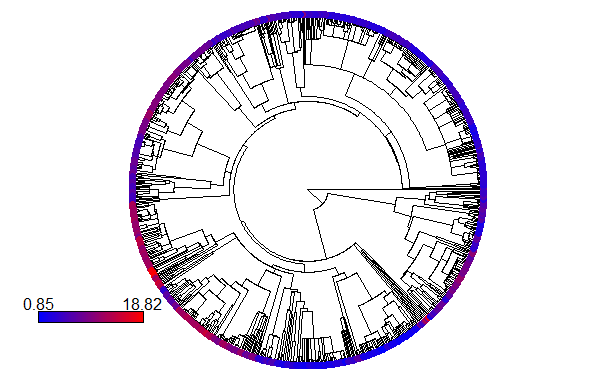

```r
color.legend(-255,-125,-155,-115,legend=c(0.85,18.82),rect.col=color.gradient(c(0,1),0,c(1,0)),gradient="x")
```

The heaviest mammal in the tree is the blue whale (Balaenoptera musculus) and the lightest are three species of shrew from the genus Suncus.

$C\cdot E$:

```r
mammal_log_C_E<-completecase_species$log_C_E[completecase_species$class=="Mammalia"]
names(mammal_log_C_E)<-completecase_species$taxaname[completecase_species$class=="Mammalia"]
mammal_log_C_E_tiporder<-mammal_log_C_E[pruned_mammaltree_best$tip.label]
plot(pruned_mammaltree_best,no.margin = TRUE,type="fan",show.tip.label = FALSE)
tiplabels(pch=19,col=color.scale(mammal_log_C_E_tiporder,extremes=c("blue","red"),xrange=c(-2.760842,5.378637)))
```

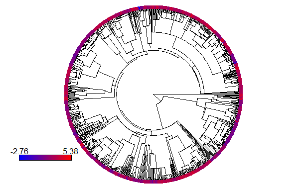

```r
color.legend(-255,-125,-155,-115,legend=c(-2.76,5.38),rect.col=color.gradient(c(0,1),0,c(1,0)),gradient="x")
```

Marmosa mexicana (Mexican mouse opossum) has the highest $C\cdot E$ value and Geomys pinetis (Southeastern pocket gopher) has the lowest.

$E/\alpha$:

```r
mammal_log_E_alpha<-completecase_species$log_E_alpha[completecase_species$class=="Mammalia"]
names(mammal_log_E_alpha)<-completecase_species$taxaname[completecase_species$class=="Mammalia"]
mammal_log_E_alpha_tiporder<-mammal_log_E_alpha[pruned_mammaltree_best$tip.label]
plot(pruned_mammaltree_best,no.margin = TRUE,type="fan",show.tip.label = FALSE)
tiplabels(pch=19,col=color.scale(mammal_log_E_alpha_tiporder,extremes=c("blue","red")))
```

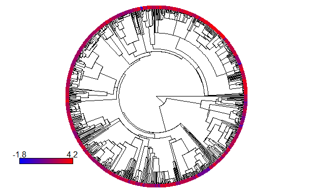

```r
color.legend(-255,-125,-155,-115,legend=c(-1.80,4.20),rect.col=color.gradient(c(0,1),0,c(1,0)),gradient="x")
```

Podomys floridanus (Florida mouse) has the highest $E/\alpha$ value and Murexechinus melanurus (black-tailed dasyure) has the lowest.

$I/m$:

```r
mammal_log_I_m<-completecase_species$log_I_m[completecase_species$class=="Mammalia"]
names(mammal_log_I_m)<-completecase_species$taxaname[completecase_species$class=="Mammalia"]
mammal_log_I_m_tiporder<-mammal_log_I_m[pruned_mammaltree_best$tip.label]
plot(pruned_mammaltree_best,no.margin = TRUE,type="fan",show.tip.label = FALSE)
tiplabels(pch=19,col=color.scale(mammal_log_I_m_tiporder,extremes=c("blue","red")))
```

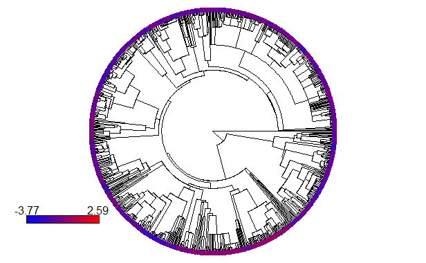

```r
color.legend(-255,-125,-155,-115,legend=c(-3.77,2.59),rect.col=color.gradient(c(0,1),0,c(1,0)),gradient="x")
```

Enhydra lutris (sea otter) has the highest $I/m$ value, although we believe that there is most likely an error in the data for this species since the recorded adult body mass is far too low to be realistic. Dasyurus geoffroii (Western quoll) has the lowest $I/m$ value, which makes sense due to the incredibly low mass of juvenile marsupials.

#### Macroevolutionary Models

I fit Brownian motion, Ornstein-Uhlenbeck, and Pagel’s lambda models to each of the four traits and noted the model with the lowest AIC score for each trait.

In order to run these models, I first needed to make the mammal phylogeny dichotomous:

```r
pruned_mammaltree_di<-multi2di(pruned_mammaltree_best,random=FALSE)
```

Body mass:

```r
mammal_bodymass_fit.ou<-fitContinuous(pruned_mammaltree_di,mammal_log_bodymass_tiporder,model="OU")
mammal_bodymass_fit.ou
```

```
GEIGER-fitted comparative model of continuous data
 fitted ‘OU’ model parameters:
    alpha = 0.000000
    sigsq = 0.046532
    z0 = 7.147611

 model summary:
    log-likelihood = -1030.677477
    AIC = 2067.354954
    AICc = 2067.383870
    free parameters = 3

Convergence diagnostics:
    optimization iterations = 100
    failed iterations = 0
    frequency of best fit = 0.61

 object summary:
    'lik' -- likelihood function
    'bnd' -- bounds for likelihood search
    'res' -- optimization iteration summary
    'opt' -- maximum likelihood parameter estimates
```

```r
mammal_bodymass_fit.bm<-fitContinuous(pruned_mammaltree_di,mammal_log_bodymass_tiporder,model="BM")
mammal_bodymass_fit.bm
```

```
GEIGER-fitted comparative model of continuous data
 fitted ‘BM’ model parameters:
    sigsq = 0.046532
    z0 = 7.147611

 model summary:
    log-likelihood = -1030.677477
    AIC = 2065.354954
    AICc = 2065.369395
    free parameters = 2

Convergence diagnostics:
    optimization iterations = 100
    failed iterations = 0
    frequency of best fit = 1.00

 object summary:
    'lik' -- likelihood function
    'bnd' -- bounds for likelihood search
    'res' -- optimization iteration summary
    'opt' -- maximum likelihood parameter estimates
```

```r
mammal_bodymass_fit.lambda<-fitContinuous(pruned_mammaltree_di,mammal_log_bodymass_tiporder,model="lambda")
mammal_bodymass_fit.lambda
```

```
GEIGER-fitted comparative model of continuous data
 fitted ‘lambda’ model parameters:
    lambda = 0.997349
    sigsq = 0.039890
    z0 = 7.146912

 model summary:
    log-likelihood = -990.601598
    AIC = 1987.203196
    AICc = 1987.232112
    free parameters = 3

Convergence diagnostics:
    optimization iterations = 100
    failed iterations = 0
    frequency of best fit = 0.01

 object summary:
    'lik' -- likelihood function
    'bnd' -- bounds for likelihood search
    'res' -- optimization iteration summary
    'opt' -- maximum likelihood parameter estimates
```

The lambda model has the best fit for body mass.

$C\cdot E$:

```r
mammal_C_E_fit.ou<-fitContinuous(pruned_mammaltree_di,mammal_log_C_E_tiporder,model="OU")
mammal_C_E_fit.ou
```

```
GEIGER-fitted comparative model of continuous data
 fitted ‘OU’ model parameters:
    alpha = 0.049683
    sigsq = 0.093331
    z0 = 2.339641

 model summary:
    log-likelihood = -1001.934441
    AIC = 2009.868882
    AICc = 2009.897797
    free parameters = 3

Convergence diagnostics:
    optimization iterations = 100
    failed iterations = 0
    frequency of best fit = 0.15

 object summary:
    'lik' -- likelihood function
    'bnd' -- bounds for likelihood search
    'res' -- optimization iteration summary
    'opt' -- maximum likelihood parameter estimates
```

```r
mammal_C_E_fit.bm<-fitContinuous(pruned_mammaltree_di,mammal_log_C_E_tiporder,model="BM")
mammal_C_E_fit.bm
```

```
GEIGER-fitted comparative model of continuous data
 fitted ‘BM’ model parameters:
    sigsq = 0.056476
    z0 = 2.060281

 model summary:
    log-likelihood = -1111.439978
    AIC = 2226.879956
    AICc = 2226.894397
    free parameters = 2

Convergence diagnostics:
    optimization iterations = 100
    failed iterations = 0
    frequency of best fit = 1.00

 object summary:
    'lik' -- likelihood function
    'bnd' -- bounds for likelihood search
    'res' -- optimization iteration summary
    'opt' -- maximum likelihood parameter estimates
```

```r
mammal_C_E_fit.lambda<-fitContinuous(pruned_mammaltree_di,mammal_log_C_E_tiporder,model="lambda")
mammal_C_E_fit.lambda
```

```
GEIGER-fitted comparative model of continuous data
 fitted ‘lambda’ model parameters:
    lambda = 0.943455
    sigsq = 0.016684
    z0 = 2.071080

 model summary:
    log-likelihood = -875.139873
    AIC = 1756.279746
    AICc = 1756.308662
    free parameters = 3

Convergence diagnostics:
    optimization iterations = 100
    failed iterations = 0
    frequency of best fit = 0.15

 object summary:
    'lik' -- likelihood function
    'bnd' -- bounds for likelihood search
    'res' -- optimization iteration summary
    'opt' -- maximum likelihood parameter estimates
```

The lambda model also has the best fit for $C\cdot E$.

$E/\alpha$:

```r
mammal_E_alpha_fit.ou<-fitContinuous(pruned_mammaltree_di,mammal_log_E_alpha_tiporder,model="OU")
mammal_E_alpha_fit.ou
```

```
GEIGER-fitted comparative model of continuous data
 fitted ‘OU’ model parameters:
    alpha = 0.022287
    sigsq = 0.029875
    z0 = 2.342369

 model summary:
    log-likelihood = -680.292905
    AIC = 1366.585810
    AICc = 1366.614726
    free parameters = 3

Convergence diagnostics:
    optimization iterations = 100
    failed iterations = 0
    frequency of best fit = 0.14

 object summary:
    'lik' -- likelihood function
    'bnd' -- bounds for likelihood search
    'res' -- optimization iteration summary
    'opt' -- maximum likelihood parameter estimates
```

```r
mammal_E_alpha_fit.bm<-fitContinuous(pruned_mammaltree_di,mammal_log_E_alpha_tiporder,model="BM")
mammal_E_alpha_fit.bm
```

```
GEIGER-fitted comparative model of continuous data
 fitted ‘BM’ model parameters:
    sigsq = 0.021635
    z0 = 2.550153

 model summary:
    log-likelihood = -711.320842
    AIC = 1426.641685
    AICc = 1426.656125
    free parameters = 2

Convergence diagnostics:
    optimization iterations = 100
    failed iterations = 0
    frequency of best fit = 1.00

 object summary:
    'lik' -- likelihood function
    'bnd' -- bounds for likelihood search
    'res' -- optimization iteration summary
    'opt' -- maximum likelihood parameter estimates
```

```r
mammal_E_alpha_fit.lambda<-fitContinuous(pruned_mammaltree_di,mammal_log_E_alpha_tiporder,model="lambda")
mammal_E_alpha_fit.lambda
```

```
GEIGER-fitted comparative model of continuous data
 fitted ‘lambda’ model parameters:
    lambda = 0.991758
    sigsq = 0.017914
    z0 = 2.549198

 model summary:
    log-likelihood = -697.621352
    AIC = 1401.242705
    AICc = 1401.271621
    free parameters = 3

Convergence diagnostics:
    optimization iterations = 100
    failed iterations = 0
    frequency of best fit = 0.01

 object summary:
    'lik' -- likelihood function
    'bnd' -- bounds for likelihood search
    'res' -- optimization iteration summary
    'opt' -- maximum likelihood parameter estimates
```

The Ornstein-Uhlenbeck model has the best fit for $E/\alpha$.

$I/m$:

```r
mammal_I_m_fit.ou<-fitContinuous(pruned_mammaltree_di,mammal_log_I_m_tiporder,model="OU")
mammal_I_m_fit.ou
```

```
GEIGER-fitted comparative model of continuous data
 fitted ‘OU’ model parameters:
    alpha = 0.051801
    sigsq = 0.043442
    z0 = -1.149564

 model summary:
    log-likelihood = -672.930171
    AIC = 1351.860342
    AICc = 1351.889257
    free parameters = 3

Convergence diagnostics:
    optimization iterations = 100
    failed iterations = 0
    frequency of best fit = 0.04

 object summary:
    'lik' -- likelihood function
    'bnd' -- bounds for likelihood search
    'res' -- optimization iteration summary
    'opt' -- maximum likelihood parameter estimates
```

```r
mammal_I_m_fit.bm<-fitContinuous(pruned_mammaltree_di,mammal_log_I_m_tiporder,model="BM")
mammal_I_m_fit.bm
```

```
GEIGER-fitted comparative model of continuous data
 fitted ‘BM’ model parameters:
    sigsq = 0.026589
    z0 = -1.432544

 model summary:
    log-likelihood = -797.308301
    AIC = 1598.616603
    AICc = 1598.631043
    free parameters = 2

Convergence diagnostics:
    optimization iterations = 100
    failed iterations = 0
    frequency of best fit = 1.00

 object summary:
    'lik' -- likelihood function
    'bnd' -- bounds for likelihood search
    'res' -- optimization iteration summary
    'opt' -- maximum likelihood parameter estimates
```

```r
mammal_I_m_fit.lambda<-fitContinuous(pruned_mammaltree_di,mammal_log_I_m_tiporder,model="lambda")
mammal_I_m_fit.lambda
```

```
GEIGER-fitted comparative model of continuous data
 fitted ‘lambda’ model parameters:
    lambda = 0.889051
    sigsq = 0.004966
    z0 = -1.419245

 model summary:
    log-likelihood = -502.390245
    AIC = 1010.780490
    AICc = 1010.809405
    free parameters = 3

Convergence diagnostics:
    optimization iterations = 100
    failed iterations = 0
    frequency of best fit = 0.11

 object summary:
    'lik' -- likelihood function
    'bnd' -- bounds for likelihood search
    'res' -- optimization iteration summary
    'opt' -- maximum likelihood parameter estimates
```

6 The lambda model once again has the best fit for $I/m$.

#### Ancestral Reconstruction

Next, I performed ancestral reconstruction on the four traits using the macroevolutionary models with lowest AIC scores from the previous section.

Body mass:

```r
mammal_bodymass_lam_tree<-rescale(pruned_mammaltree_best,model="lambda", mammal_bodymass_fit.lambda$opt$lambda)
mammal_bodymass_lam_fastAnc<-fastAnc(mammal_bodymass_lam_tree, mammal_log_bodymass_tiporder)
```

$C\cdot E$:

```r
mammal_C_E_lam_tree<-rescale(pruned_mammaltree_best,model="lambda", mammal_C_E_fit.lambda$opt$lambda)
mammal_C_E_lam_fastAnc<-fastAnc(mammal_C_E_lam_tree, mammal_log_C_E_tiporder)
```

$E/\alpha$:

```r
mammal_E_alpha_ou_tree<-rescale(pruned_mammaltree_best,model="OU", mammal_E_alpha_fit.ou$opt$alpha)
mammal_E_alpha_ou_fastAnc<-fastAnc(mammal_E_alpha_ou_tree, mammal_log_E_alpha_tiporder)
```

$I/m$:

```r
mammal_I_m_lam_tree<-rescale(pruned_mammaltree_best,model="lambda", mammal_I_m_fit.lambda$opt$lambda)
mammal_I_m_lam_fastAnc<-fastAnc(mammal_I_m_lam_tree, mammal_log_I_m_tiporder)
```